# Informe Técnico: Análisis de Datos de Velocidad ANT

Análisis Exploratorio y Cálculo de Parámetros de Simulación

Grupo 2: Freddy Guaman, Marjorie Jimenez, Cristina Orellana

2026-01-12

# 1. Dataset y Limpieza de Datos (5560)

## Descripción Técnica del Dataset

El análisis se basa en el archivo `ant-exceso-velocidad-febrero-2022.csv`. Para garantizar la validez de la simulación, se aplicó un proceso de limpieza riguroso (Script `01_load_clean.R`):

1. **Filtrado Temporal:** Se restringieron los datos estrictamente a **Febrero 2022** para asegurar un cálculo consistente de las tasas de llegada diarias.
2. **Eliminación de Outliers:** Se descartaron registros con velocidades > 200 km/h (errores de GPS) y <= 0 km/h.
3. **Variables Derivadas:** Se generaron atributos como `franja_horaria` (Madrugada, Mañana, Tarde, Noche) para simplificar la configuración de los “Sources” en la simulación.

## Evolución del Dataset

Comparativa entre la estructura original y el resultado final procesado:

**Problemas Identificados:** * Fechas como texto. * Coordenadas y decimales con comas. * **Valores Sucios:** Registros vacíos (`NA`), velocidades negativas o por errores de sensor.

## Diccionario de Varibales Generado

A continuación se detallan las variables disponibles en el dataset procesado `dataset_limpio.csv`:

Estructura del Dataset Limpio

| variable | tipo | descripcion |
| --- | --- | --- |
| PROVINCIA_OPERADORA | factor | Provincia de la operadora |
| CIUDAD_OPERADORA | character | Ciudad de la operadora |
| IDENTIFICACION_OPERADORA | character | ID operadora |
| TIPO_OPERADORA | factor | Tipo operadora |
| LATITUD | numeric | Latitud evento |
| LONGITUD | numeric | Longitud evento |
| UBICACION_EXCESO | character | Ubicación textual |
| CIUDAD_EXCESO | character | Ciudad evento |
| PROVINCIA_EXCESO | factor | Provincia evento |
| FECHA_ALERTA | character | Fecha original (texto) |
| HORA_ALERTA | hms/difftime | Hora original (texto) |
| VELOCIDAD | numeric | Velocidad registrada |
| TIPO_EXCESO | factor | Tipo de exceso |
| FECHA_ALERTA_DT | Date | Fecha formato Date |
| HORA_ALERTA_NUM | integer | Hora formato entero |
| dia_num | numeric | Número de día (1=Lun) |
| franja_horaria | factor | Franja horaria (cat) |
| dia_semana | factor | Día de la semana (factor) |

# 2. Análisis Exploratorio y Visualizaciones

Se presentan las visualizaciones generadas por el script `02_visualizations.R`, con su respectiva interpretación para el modelado en software de simulación.

## A. Demanda en el Tiempo

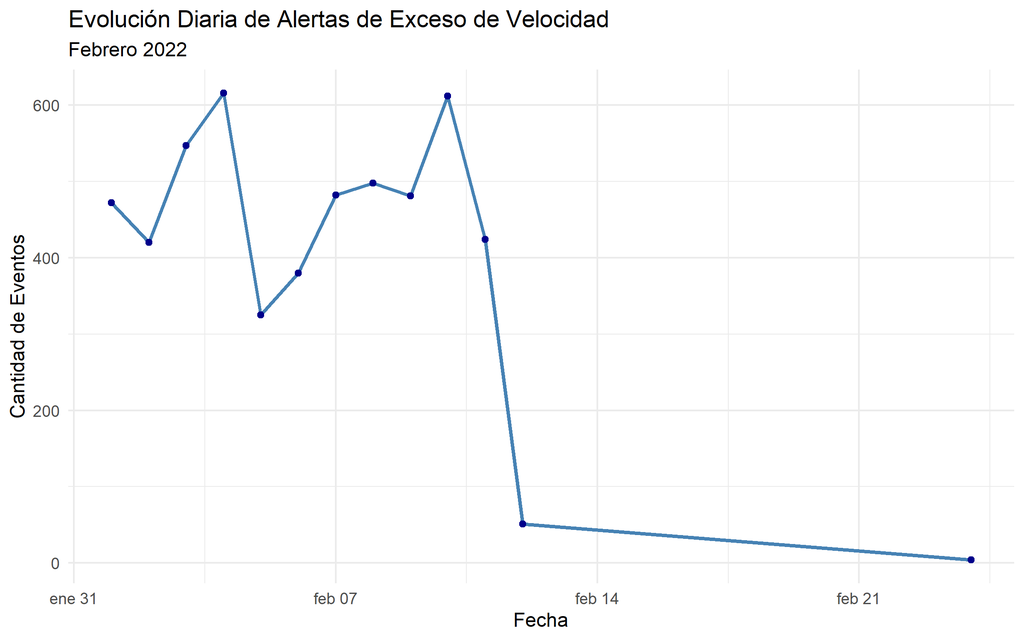

## Evolución Diaria

Este gráfico nos muestra cuántas infracciones ocurren cada día del mes.

**¿Qué observamos?** Podemos ver claramente qué días hay más actividad y si existen momentos de calma durante el mes.

## B. Distribución de Velocidad

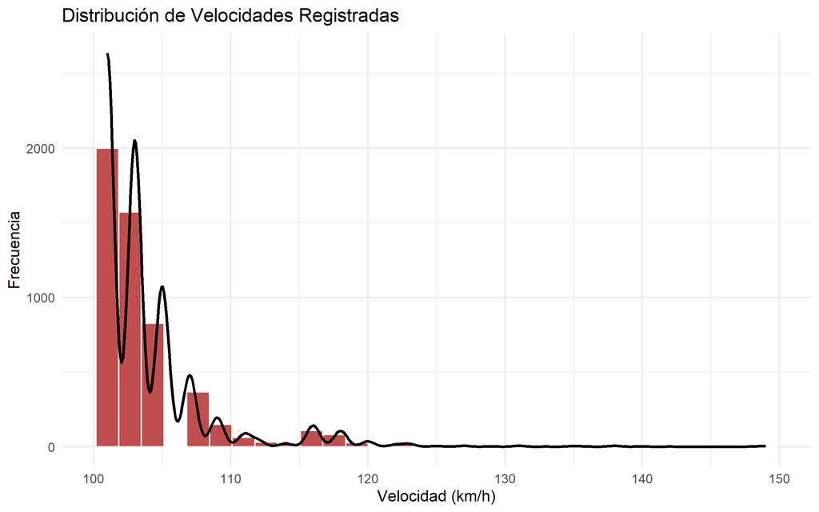

## Velocidades Frecuentes

Aquí vemos qué tan rápido van los vehículos infractores.

**¿Qué observamos?** Nos indica la velocidad más común. Nos ayuda a entender qué tan grave es el problema

## C. Tipos de Exceso

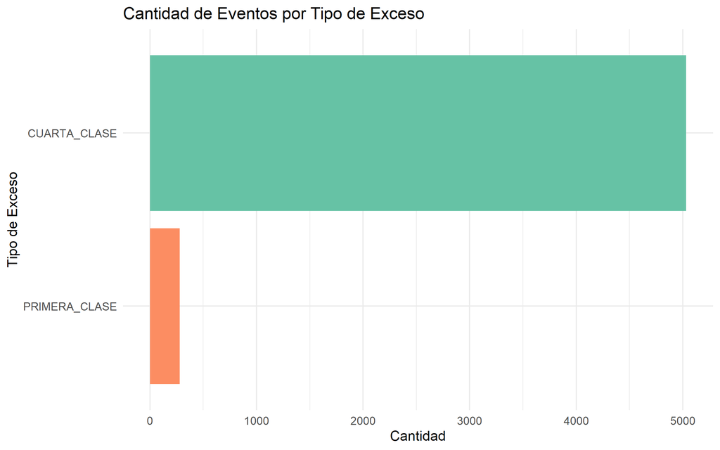

## Categorías Principales

**Tipos de exceso de velocidad:**

- **Clase I (Grave):** Exceso de velocidad muy alto y de alto riesgo.
- **Clase II:** Exceso considerable con riesgo elevado.
- **Clase III:** Exceso moderado de riesgo medio.
- **Clase IV (Leve):** Exceso leve dentro del rango técnico; es el más frecuente.

**¿Qué observamos?** El gráfico muestra qué tipo de infracción se presenta con mayor frecuencia. Generalmente predomina la Clase IV, lo que indica que el control debe enfocarse en excesos leves pero recurrentes.

## D. Mapa de Calor

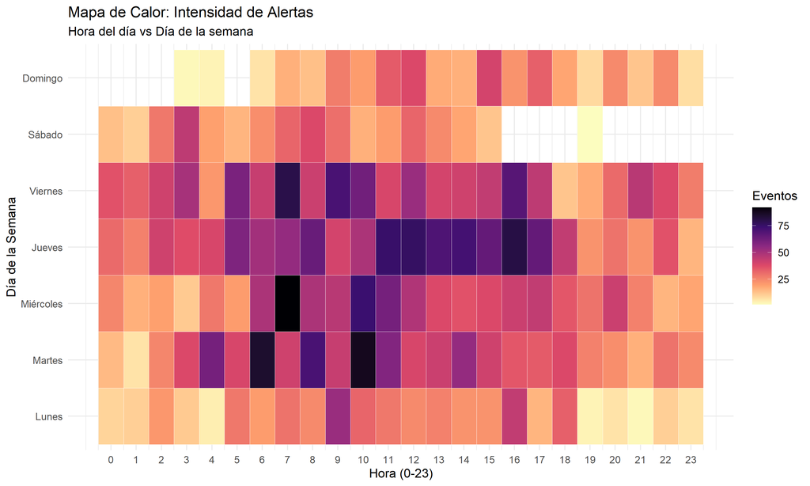

## Puntos Calientes

Combina hora y día para encontrar los momentos críticos.

## E. Ubicaciones (Top Provincias)

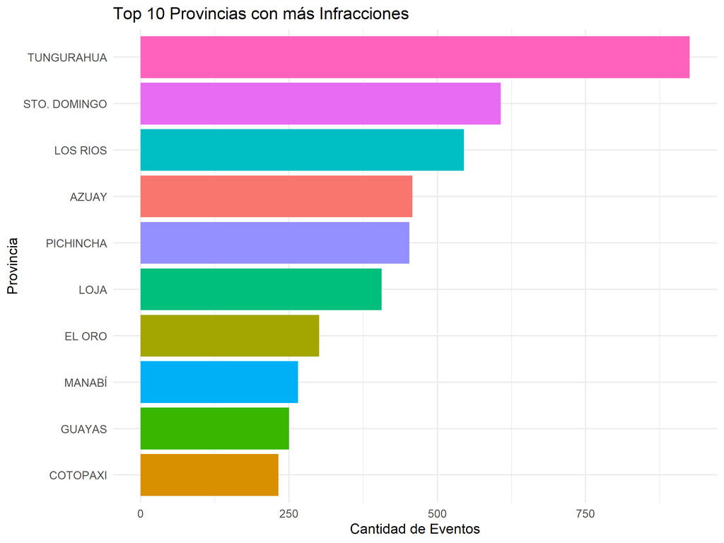

## Regiones Críticas

Identificamos las provincias dónde más se reportan excesos.

**¿Qué observamos?** Vemos geográficamente dónde está el problema. Usualmente, provincias con grandes autopistas encabezan la lista debido al mayor flujo vehicular.

## F. Tipo de Transporte

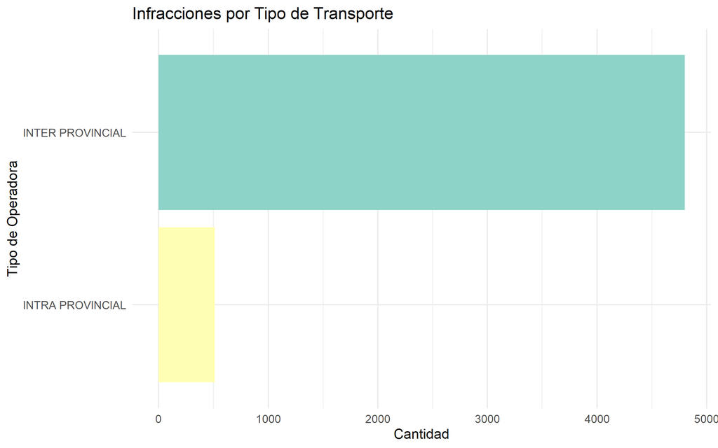

## Operadoras Involucradas

Analizamos quiénes cometen las infracciones.

**¿Qué observamos?** Podemos ver si el problema es generalizado o específico de ciertas cooperativas ( Interprovinciales, Intraprovinciales). Esto ayuda a dirigir las capacitaciones.

# 3. Parámetros para la Simulación

A continuación se presentan los parámetros que configuran el modelo de simulación.

Tabla Maestra de Configuración

| parámetro | valor | unidad | descripción |
| --- | --- | --- | --- |
| Tasa_Llegada_Global | 221.3300 | eventos/día | Frecuencia promedio de infracciones registradas por día. |
| Tasa_Llegada_Madrugada | 6.9000 | eventos/hora | Frecuencia promedio de infracciones por hora en la madrugada. |
| Tasa_Llegada_Mañana | 13.1100 | eventos/hora | Frecuencia promedio de infracciones por hora en la mañana. |
| Tasa_Llegada_Noche | 5.6500 | eventos/hora | Frecuencia promedio de infracciones por hora en la noche. |
| Tasa_Llegada_Tarde | 11.2200 | eventos/hora | Frecuencia promedio de infracciones por hora en la tarde. |
| Velocidad_Promedio | 104.0800 | km/h | Velocidad promedio de los vehículos infractores. |
| Velocidad_Mediana | 103.0000 | km/h | Valor central de la distribución de velocidades. |
| Velocidad_DesvStd | 4.7000 | km/h | Medida de la dispersión de las velocidades respecto al promedio. |
| Prob_Tipo_CUARTA_CLASE | 0.9473 | probabilidad | Probabilidad de que una infracción corresponda a la cuarta clase. |
| Prob_Tipo_PRIMERA_CLASE | 0.0527 | probabilidad | Probabilidad de que una infracción corresponda a la primera clase. |
| Prob_Transporte_INTERPROVINCIAL | 0.9036 | probabilidad | Probabilidad de que el servicio sea interprovincial. |
| Prob_Transporte_INTRAPROVINCIAL | 0.0964 | probabilidad | Probabilidad de que el servicio sea intraprovincial. |
| Prob_Provincia_TUNGURAHUA | 0.1741 | probabilidad | Probabilidad de ocurrencia en la provincia de Tungurahua. |
| Prob_Provincia_STO_DOMINGO | 0.1143 | probabilidad | Probabilidad de ocurrencia en la provincia de Santo Domingo. |
| Prob_Provincia_LOS_RIOS | 0.1026 | probabilidad | Probabilidad de ocurrencia en la provincia de Los Ríos. |